# final

Nan Tang

6/6/2020

## Problem 1

### (a)

If no split is allowed, we will classify all query points as $y = 0$, since $p(y = 0) = \frac{7}{8}$ greater than $p(y = 1) = \frac{1}{8}$.

In this case risk is probability of misclassifying $y = 1$ as $y = 0$
$$\begin{aligned}
p(risk) = p(y = 1) = \frac{1}{8}
\end{aligned}$$

### (b)

$$\begin{aligned}
p(y = 0 | x \in [1, 3] \times [0, 3]) &= 1 \\
p(y = 1 | x \in [1, 3] \times [0, 3]) &= 0 \\
p(y = 0 | x \in [0, 1] \times [0, 3]) &= \frac{p(x \in [0, 1] \times [0, 3] | y=0) \cdot p(y=0)}{p(x \in [0, 1] \times [0, 3])} = \frac{7}{10} \\
p(y = 1 | x \in [0, 1] \times [0, 3]) &= 1 - p(y = 0 | x \in [0, 1] \times [0, 3]) = \frac{3}{10}
\end{aligned}$$

By minimum risk prediction rule, we will classify both left and right leaves as $y = 0$.

This vertical split failed to reduce misclassification risk.

### (c)

If only one split is allowed, there is no way to reduce misclassification risk.

### (d)

By rule of probabilistic classification, probability of classify query point $(x_0, y_0)$ as $\hat{y_0}=1$ equals marginal probability of $y=1$ which is $\frac{1}{8}$; probability of classify query point $(x_0, y_0)$ as $\hat{y_0}=0$ equals marginal probability of $y=0$ which is $\frac{7}{8}$.

$$\begin{aligned}
p(risk) &= p(\hat{y_0}=1 \text{ and } y_0 = 0) + p(\hat{y_0}=0 \text{ and } y_0 = 1) \\
&= p(\hat{y_0}=1) \cdot p( y_0 = 0) + p(\hat{y_0}=0) \cdot p( y_0 = 1) \\
&= \frac{7}{32}
\end{aligned}$$

### (e)

Marginal probability distribution for $x$ can be represent as:
$$\begin{aligned}
p(x \in [0, 1] \times [0, 3]) &= p(x \in [0, 1] \times [0, 3] | y=0) \cdot p(y=0) + p(x \in [0, 1] \times [0, 3] | y=1) \cdot p(y=1) \\
&= \frac{1}{3} \cdot \frac{7}{8} + 1 \cdot \frac{1}{8} \\
&= \frac{5}{12}
\end{aligned}$$

$$\begin{aligned}
p(y = 0 | x \in [1, 3] \times [0, 3]) &= 1 \\
p(y = 1 | x \in [1, 3] \times [0, 3]) &= 0 \\
p(y = 0 | x \in [0, 1] \times [0, 3]) &= \frac{p(x \in [0, 1] \times [0, 3] | y=0) \cdot p(y=0)}{p(x \in [0, 1] \times [0, 3])} = \frac{7}{10} \\
p(y = 1 | x \in [0, 1] \times [0, 3]) &= 1 - p(y = 0 | x \in [0, 1] \times [0, 3]) = \frac{3}{10}
\end{aligned}$$

By probabilistic classification rule, for $x_0 \in N_r$, probability of classify $\hat{y_0} = 0$ is 1; for $x_0 \in N_l$, probability of classify $\hat{y_0} = 0$ is $\frac{7}{10}$, and probability of classify $\hat{y_0} =1$ is $\frac{3}{10}$.

In this case, risk only exists in left leaf, where $x \in [0, 1] \times [0, 3]$

$$\begin{aligned}
p(risk) &= p(\hat{y_0} = 1 \text{ and } y_0 = 0) + p(\hat{y_0} = 0 \text{ and } y_0 = 1) \\
&= p(\hat{y_0} = 1, y_0 = 0 | x \in [0, 1] \times [0, 3]) \cdot p(x \in [0, 1] \times [0, 3]) + p(\hat{y_0} = 0, y_0 = 1 | x \in [0, 1] \times [0, 3]) \cdot p(x \in [0, 1] \times [0, 3]) \\
&= (\frac{7}{10} \cdot \frac{3}{10} \cdot 2) \cdot \frac{5}{12}\\
&= \frac{7}{40}
\end{aligned}$$

Compare to previous one, this split reduced risk from $\frac{7}{32}$ to $\frac{7}{40}$.

### (f)

A horizontal split can be applied, by deviding X into two parts: $[0, 3] \times [0, 1]$ and $[0, 3] \times [1, 3]$. Decision rule will be similiar to pervious split.

Risk doesn’t exist on leaf $X \in [0, 3] \times [1, 3]$; risk on small leaf $x \in [0, 3] \times [0, 1]$ is $\frac{7}{40}$ as well.

Split mothods in part (e) and (f) are both optimized in reducing misclassification risk, therefore, (f) has equivlent risk comparing to (e).

## Problem 2

### (a)

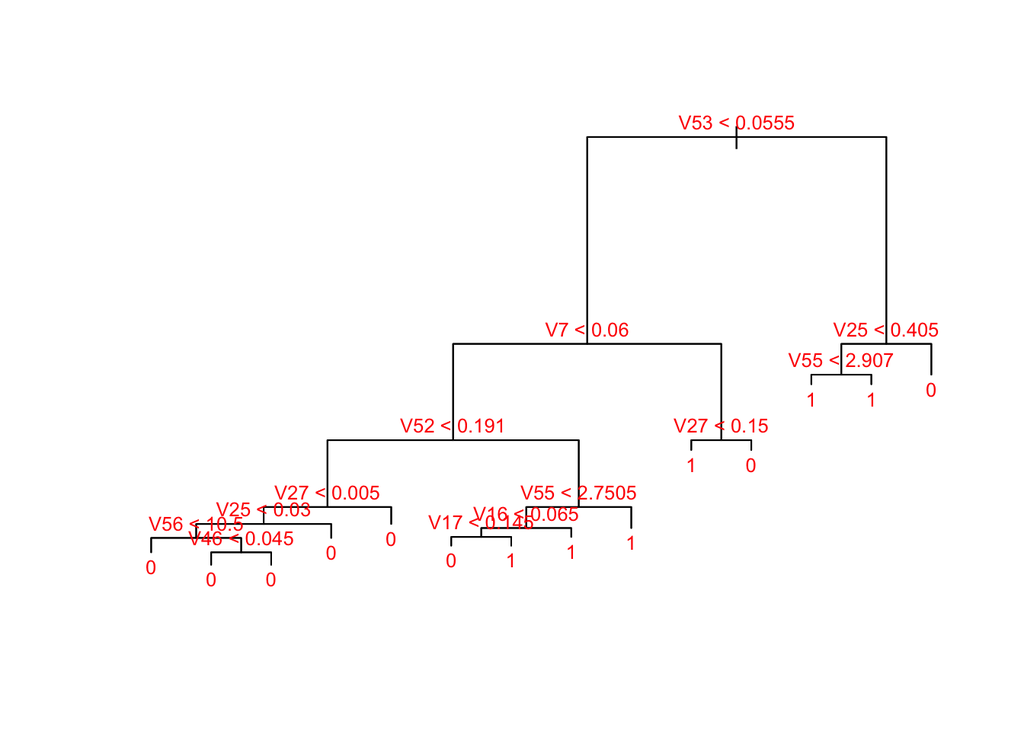

```r
## train test split
spam_dt <- read.table('spam.data', sep=' ')
spam_dt$V58 <- as.factor(spam_dt$V58)

split_index <- read.table('spam.traintest', sep=' ')

spam_train <- spam_dt[which(split_index$V1 == 0),]
spam_test <- spam_dt[which(split_index$V1 == 1),]

train_tree <- tree(formula = V58~., data=spam_train)

plot(train_tree)
text(train_tree, col='red', cex=0.8)
```

```r
## predictions
train_pred <- predict(train_tree, spam_train, type='class')
train_pred_tb <- table(spam_train$V58, train_pred)
train_err <- (train_pred_tb[1, 2] + train_pred_tb[2, 1]) / length(train_pred)
cat('training error rate: ', train_err)
```

```
## training error rate:  0.08482871
```

```r
test_pred <- predict(train_tree, spam_test, type='class')
test_pred_tb <- table(spam_test$V58, test_pred)
test_err <- (test_pred_tb[1, 2] + test_pred_tb[2, 1]) / length(test_pred)
cat('test error rate: ', test_err)
```

```
## test error rate:  0.1002604
```

### (b)

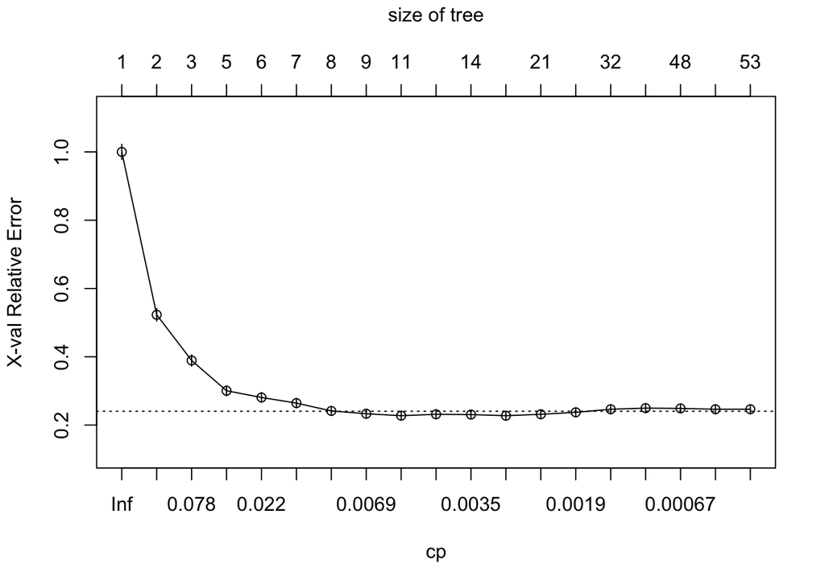

```r
set.seed(123)

train_rpart <- rpart(formula = V58~., data=spam_train, method='class', cp=0.0001)

plotcp(train_rpart)
```

```r
printcp(train_rpart)
```

```
##
## Classification tree:
## rpart(formula = V58 ~ ., data = spam_train, method = "class",
##     cp = 1e-04)
##
## Variables actually used in tree construction:
##  [1] V12 V16 V17 V18 V19 V21 V24 V25 V27 V39 V42 V45 V46 V5  V50 V52 V53 V55 V56
## [20] V57 V6  V7  V9
##
## Root node error: 1218/3065 = 0.39739
##
## n= 3065
##
##            CP nsplit rel error  xerror     xstd
## 1  0.49343186      0   1.00000 1.00000 0.022243
## 2  0.14449918      1   0.50657 0.52299 0.018443
## 3  0.04187192      2   0.36207 0.38916 0.016435
## 4  0.02791461      4   0.27833 0.30049 0.014739
## 5  0.01724138      5   0.25041 0.28079 0.014311
## 6  0.01149425      6   0.23317 0.26437 0.013937
## 7  0.00821018      7   0.22167 0.24138 0.013385
## 8  0.00574713      8   0.21346 0.23317 0.013179
## 9  0.00410509     10   0.20197 0.22742 0.013032
## 10 0.00369458     11   0.19787 0.23153 0.013138
## 11 0.00328407     13   0.19048 0.23071 0.013117
## 12 0.00246305     14   0.18719 0.22742 0.013032
## 13 0.00218938     20   0.17241 0.23153 0.013138
## 14 0.00164204     23   0.16585 0.23727 0.013283
## 15 0.00102627     31   0.15271 0.24631 0.013507
## 16 0.00082102     44   0.13629 0.24959 0.013586
## 17 0.00054735     47   0.13383 0.24877 0.013567
## 18 0.00041051     50   0.13218 0.24631 0.013507
## 19 0.00010000     52   0.13136 0.24631 0.013507
```

Refer to ‘one standard error’ rule, suppose $\lambda^* = argmin_{\lambda_i}(CV error)$, we will choose simplest (biggest $\lambda$) model such that $CV(\lambda) \leq SE(\lambda_i) + CV(\lambda^*)$.

The horizontal dotted line in plot indicates one standard error in addition to minimum cross-validation error. Points that below the dotted line are within the satisfied region. We can perceive tree with nine nodes (eight splits) is the simpliest model satisfying the rule.

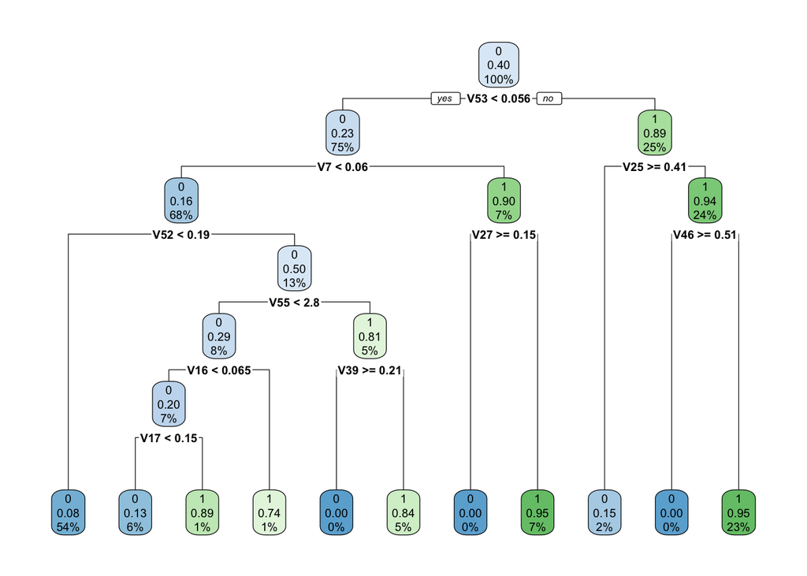

```r
opt_tree <- prune(train_rpart, cp=0.0057)

rpart.plot(opt_tree)
```

```r
## predictions
train_pred <- predict(opt_tree, spam_train, type='class')
train_pred_tb <- table(spam_train$V58, train_pred)
train_err <- (train_pred_tb[1, 2] + train_pred_tb[2, 1]) / length(train_pred)
cat('training error rate: ', train_err)
```

```
## training error rate:  0.08026101
```

```r
test_pred <- predict(opt_tree, spam_test, type='class')
test_pred_tb <- table(spam_test$V58, test_pred)
test_err <- (test_pred_tb[1, 2] + test_pred_tb[2, 1]) / length(test_pred)
cat('test error rate: ', test_err)
```

```
## test error rate:  0.09505208
```

This tree performs better than un-pruned tree on test data.

## Problem 3

### (a)

```r
# define euclidean distance
euc.dist <- function(q_pt, train_pts) {
  return(sqrt(rowSums(sweep(as.matrix(train_pts), 2, as.numeric(q_pt))**2)))
}

knn.classifier <- function(X.train, y.train, X.test, k.try=1, pi=rep(1/K, K), CV=F) {
  test_size <- nrow(X.test)
  train_size <- nrow(X.train)
  test_pred <- matrix(nrow=test_size, ncol=length(k.try))
  K <- length(levels(y.train))
  ni <- table(y.train)

  dist_matrix <- numeric(0)
  if (CV) {
    dist_matrix <- as.matrix(dist(X.train))
  }

  for (i in 1:test_size){
    query_pt <- X.test[i,]
    eu_dist <- numeric(0)
    y.train.final <- y.train

    # CV only make sense if X.train = X.test
    if (CV) {
      eu_dist <- dist_matrix[-i, i]
      y.train.final <- y.train.final[-i]
    } else {
      eu_dist <- euc.dist(query_pt, X.train)
    }

    # find k nearest training obs
    for (j in 1:length(k.try)) {
      knn_index <- which(eu_dist %in% sort(eu_dist)[1:k.try[j]])
      knn_train_label <- y.train.final[knn_index]

      knn_train_count <- table(knn_train_label)
      knn_score <- knn_train_count * pi / ni
      max_score <- max(knn_score, na.rm=TRUE)
      pred_label <- names(knn_score[which(knn_score == max_score)])

      # check if tie exists
      if (length(pred_label) > 1) {
        # random pick
        pred_label <- sample(pred_label, 1)
      }
      test_pred[i, j] <- pred_label
    }
  }
  return(test_pred)
}
```

### (b)

```r
data(iris)

X.train <- iris[, 1:4]
y.train <- iris[, 5]
```

```r
set.seed(123)

train_err <- length(which(knn.classifier(X.train, y.train, X.train, k.try=5) !=y.train))
cat('number of misclassification: ', train_err)
```

```
## number of misclassification:  5
```

```r
train_err_cv <- length(which(knn.classifier(X.train, y.train, X.train, k.try=5, CV=TRUE) !=y.train))
cat('number of misclassification (CV = True): ', train_err_cv)
```

```
## number of misclassification (CV = True):  5
```

### (c)

```r
k_ls <- c(1, 3, 7, 11, 15, 21, 27, 35, 43)

zip_train <- read.table('zip-train.dat', sep='')
X.train <- zip_train[,-1]
y.train <- as.factor(zip_train[,1])

pi_new <- table(y.train) / length(y.train)
```

```r
set.seed(123)

train_pred <- knn.classifier(X.train, y.train, X.train, pi=pi_new, k.try=k_ls, CV=TRUE)

k_err <- numeric(length(k_ls))
for (i in 1: length(k_ls)) {
  k_err[i] <- length(which(train_pred[,i] !=y.train))
}
k_err <- k_err / nrow(X.train)

cat('Optimal choice of k: ', which.min(k_err), ', with corresponding training error rate: ', min(k_err))
```

```
## Optimal choice of k:  1 , with corresponding training error rate:  0.035
```

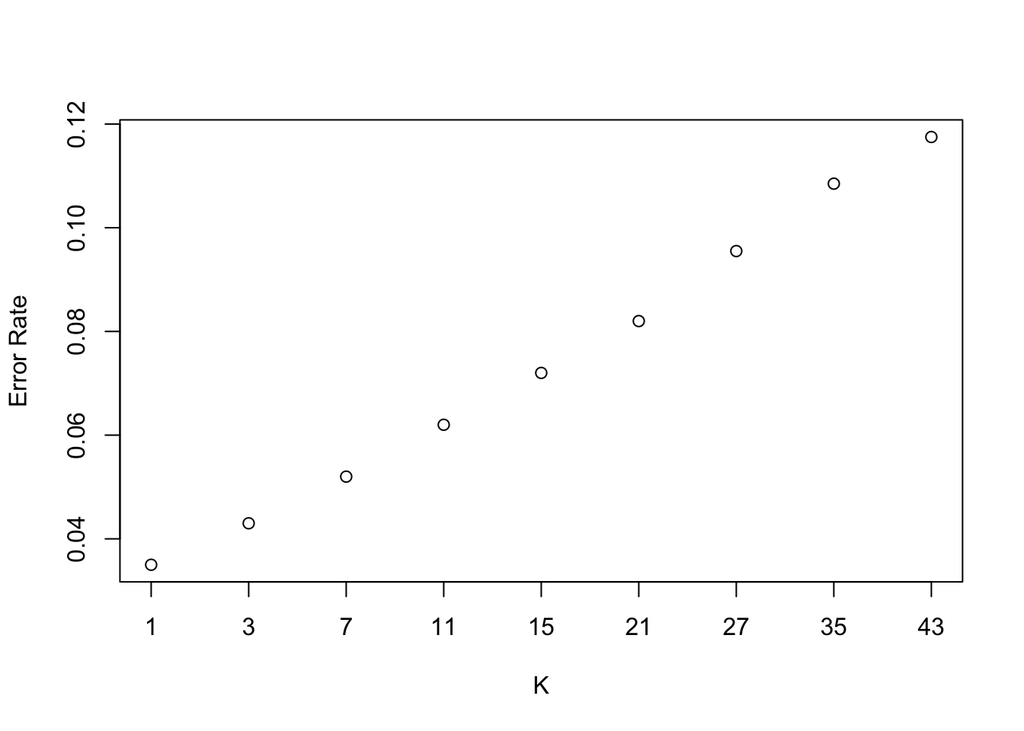

```r
plot(1:length(k_ls), k_err, xaxt='n', ylab='Error Rate', xlab='K')
axis(1, at=1:length(k_ls), labels = k_ls)
```

### (d)

```r
set.seed(123)

zip_test <- read.table('zip-test.dat', sep='')

X.test <- zip_test[, -1]
y.test <- as.factor(zip_test[,1])
```

```r
test_pred <- knn.classifier(X.train, y.train, X.test, k.try=1)

test_err <- length(which(test_pred !=y.test)) / nrow(X.test)

cat('test error rate of 1-nearest neighbor classifier: ', test_err)
```

```
## test error rate of 1-nearest neighbor classifier:  0.07922272
```